# PD_3

Konrad Welkier

24 października 2019

### Dane

Ładowanie danych i obróbka tabelki w podobny sposób, co w oryginalnej pracy domowej (główne zmiany dotyczą przetwarzania na liczby ostatnią kolumnę, w której części dziesiętne oddzielone są przecinkami).

| Data | Dobowa.prognoza.zapotrzebowania.KSE | Rzeczywiste.zapotrzebowanie.KSE |
| --- | --- | --- |
| 2019-10-17 1:00 | 16900 | 17127.17 |
| 2019-10-17 2:00 | 16400 | 16488.00 |
| 2019-10-17 3:00 | 16000 | 16231.42 |
| 2019-10-17 4:00 | 16000 | 16342.67 |
| 2019-10-17 5:00 | 16800 | 16505.06 |
| 2019-10-17 6:00 | 18200 | 17349.54 |
| 2019-10-17 7:00 | 21100 | 20256.55 |
| 2019-10-17 8:00 | 22100 | 21982.89 |
| 2019-10-17 9:00 | 22600 | 22641.21 |
| 2019-10-17 10:00 | 22400 | 22765.64 |
| 2019-10-17 11:00 | 22200 | 22390.72 |
| 2019-10-17 12:00 | 22200 | 22482.08 |
| 2019-10-17 13:00 | 22400 | 22472.78 |
| 2019-10-17 14:00 | 22400 | 22380.65 |
| 2019-10-17 15:00 | 21900 | 22032.22 |
| 2019-10-17 16:00 | 21900 | 21867.99 |
| 2019-10-17 17:00 | 21900 | 21761.03 |
| 2019-10-17 18:00 | 23000 | 22284.16 |
| 2019-10-17 19:00 | 23900 | 23507.33 |
| 2019-10-17 20:00 | 23900 | 23488.81 |
| 2019-10-17 21:00 | 23000 | NA |
| 2019-10-17 22:00 | 21400 | NA |
| 2019-10-17 23:00 | 19600 | NA |
| 2019-10-17 24:00 | 18200 | NA |

### Wykres z pierwszej pracy domowej

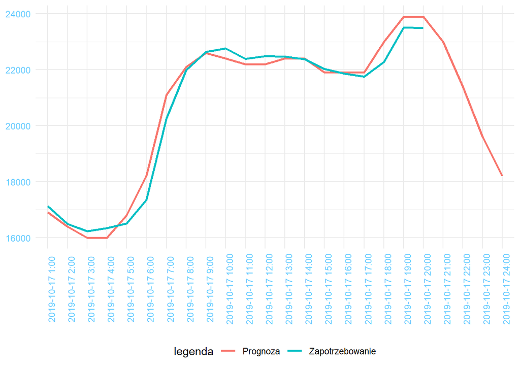

### Dodatkowa obróbka ramki danych

W tej części pracy zajmujemy się naniesieniem dodatkowych zmian do naszej ramki danych, aby na wykresie można było pokazać inne aspekty niż te, które widoczne są na wykresie oryginalnym.

| Data | Difference | IsPositive |
| --- | --- | --- |
| 2019-10-17 1:00 | 227.175 | TRUE |
| 2019-10-17 2:00 | 88.000 | TRUE |
| 2019-10-17 3:00 | 231.425 | TRUE |
| 2019-10-17 4:00 | 342.675 | TRUE |
| 2019-10-17 5:00 | -294.937 | FALSE |
| 2019-10-17 6:00 | -850.462 | FALSE |
| 2019-10-17 7:00 | -843.450 | FALSE |
| 2019-10-17 8:00 | -117.112 | FALSE |
| 2019-10-17 9:00 | 41.213 | TRUE |
| 2019-10-17 10:00 | 365.638 | TRUE |
| 2019-10-17 11:00 | 190.725 | TRUE |
| 2019-10-17 12:00 | 282.075 | TRUE |
| 2019-10-17 13:00 | 72.775 | TRUE |
| 2019-10-17 14:00 | -19.350 | FALSE |
| 2019-10-17 15:00 | 132.225 | TRUE |
| 2019-10-17 16:00 | -32.012 | FALSE |
| 2019-10-17 17:00 | -138.975 | FALSE |
| 2019-10-17 18:00 | -715.837 | FALSE |
| 2019-10-17 19:00 | -392.675 | FALSE |
| 2019-10-17 20:00 | -411.187 | FALSE |

### Nowy wykres

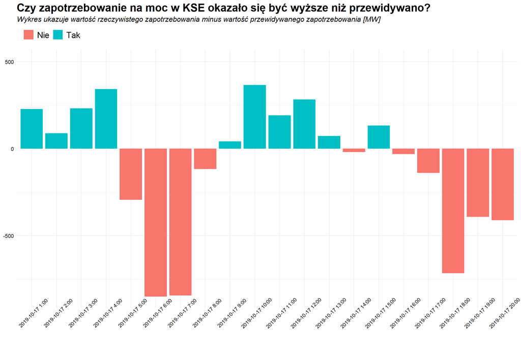

### Omówienie różnic

Wykres przygotowany przeze mnie skupia się na innych aspektach wykorzystując do tego oczywiście ten sam zbiór danych. Stwierdziłem, że warto położyć nacisk na porównanie przewidywań ekspertóW z Krajowej Sieci Energoelektrycznej z rzeczywistością i ukazać w ten sposób pewne trendy. W tym celu wziąłem tę część danych, dla których dostępne były również pomiary rzeczywiste, a więc do godziny 20. Następnie odpowiedziałem na pytanie, czy zapotrzebowanie na moc okazało się być wyższe niż podejrzewano. W tym celu na wykresie zaprezentowałem dla kolejnych godzin rozpatrywanej doby różnice pomiędzy rzeczywistym zapotrzebowaniem, a prognozą. Jak widać na podstawie legendy słupki w kolorze niebieskim wskazują na wyższe zapotrzebowanie niż się spodziewano, a słupki czerwone na sytuację odwrotną. Najciekawszym wnioskiem natomiast, jaki można wysnuć z powyższego wykresu to fakt, że eksperci ze znaczącą nadwyżką oszacowali zapotrzebowanie w “godzinach szczytu”, czyli wczesnym rankiem oraz w godzinach wieczornych, a w pozostałych godzinach, kiedy zapotrzebowanie jest trochę niższe (w ciągu reszty dnia) lub dużo niższe (w nocy) ich ocena okazała się być niedoszacowaniem, chociaż różnica między ich prognozami, a rzeczywistością (mówimy oczywiście o module z różnicy) była w tym czasie znacząco mniejsza niż podczas “godzin szczytu”.